# IE509 -- Snakes and ladders

Pedro Tabacof - 082493 - tabacof@gmail.com

This Python script calculates the PMF and CDF of finishing a Snakes and Ladder game at each round.

There are two modes, with and without torture, where the latter means the player must be exactly on the last position of the board for the game to stop (otherwise the player will go back the number of remaining steps).

I implement two methods to calculate the distributions:

- Simple simulation (easy to implement but slow and inexact)
- Markov chain (hard to implement but fast and exact)

## Simple simulation

Start at square 1, simulate dice play, move forward 1 to 6 squares, apply Snakes and Ladder teleport rules, check whether game is finished or not (and apply torture if necessary), repeat until game is finished.

Do this N times, and for each time store the round the game actually finished. Then use the empirical distribution ("histogram") to calculate the PMF and CDF.

```python
%matplotlib inline
import numpy as np
import matplotlib.pyplot as plt
import seaborn as sns
```

```python
# Board definition {starting_position:ending_position}
snakes = {97:29, 95:74, 93:53, 83:61, 79:22, 77:44, 65:2, 48:9, 41:19, 37:15}
ladders = {4:38, 6:14, 12:27, 21:78, 25:55, 33:51, 64:94, 67:88, 71:92, 80:99}

# Board update function
# Non-torture: Game finishes after the last position is reached or passed over
# Torture: Game finishes only when landing exactly on the last position (otherwise turn back)
def snakes_ladders(position, last, torture=False):
    if position in snakes: # Snake position
        return snakes[position]
    elif position in ladders: # Ladder position
        return ladders[position]
    elif torture and position > last: # Over last position (with torture)
        # Recursive call (in case of landing on a snake):
        return snakes_ladders(last - (position - last), last, torture)
    elif position > last: # Over last position (without torture)
        return last
    else: # Regular position
        return position
```

```python
# Simulates N plays of the game and returns a histogram with the last round of each play
def simulation(last_square=100, N=100000, torture=False):
    hist = []
    for i in range(N):
        current_position = 1 # Start at position 1 of the board
        current_round = 0
        while current_position != last_square:
            dice = np.random.randint(1,7) # Six-sided dice
            current_position += dice
            current_position = snakes_ladders(current_position, last_square, torture=torture)
            current_round += 1
        hist.append(current_round)
    return hist
```

```python
N = int(2e5) # Number of simulations
n_rounds = 250 # Show PMF and CDF up to this round
```

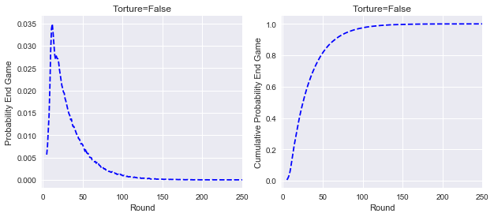

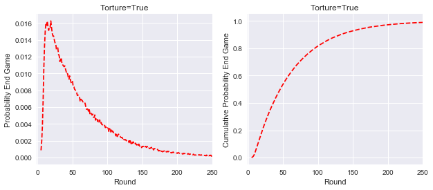

```python
# Simulation with and without torture
for torture in [False, True]:
    # Simulation:
    hist = simulation(N=N, torture=torture)
    # PMF calculation:
    rounds, counts = np.unique(hist, return_counts=True)
    # CDF calculation:
    counts = counts/N
    cumulative = np.cumsum(counts)

    # Plotting PMF and CDF respectively
    plt.figure(figsize=(10,4))

    plt.subplot(1,2,1)
    plt.plot(rounds, counts, '--', c='r' if torture else 'b', label='Regular')
    plt.xlim(-1, n_rounds)
    plt.ylabel('Probability End Game')
    plt.xlabel('Round')
    plt.title('Torture=%r' % torture)

    plt.subplot(1,2,2)
    plt.plot(rounds, cumulative, '--', c='r' if torture else 'b', label='Regular')
    plt.xlim(-1, n_rounds)
    plt.ylabel('Cumulative Probability End Game')
    plt.xlabel('Round')
    plt.title('Torture=%r' % torture)
    plt.show()
```

## Markov chain

Calculate the transition matrix first, then calculate the board state distribution for each round.

```python
# Calculate transition matrix
def transition_matrix(last_square, torture):
    snakes_ladders = {**snakes, **ladders} # Merge snakes and ladders into single entity
    snakes_ladders = {(s-1):(e-1) for s,e in snakes_ladders.items()} # Update snakes and ladders to 0-index notation
    T = np.zeros((last_square, last_square)) # Transition matrix

    ls = last_square-1 # Last square in 0-index notation

    for i in range(ls):
        # Start with the next 6 squares
        possible_moves = range(i+1, i+7)
        if torture:
            # With torture, go back if over last_square
            possible_moves = [ls-(pm-ls) if pm > ls else pm for pm in possible_moves]
        else:
            # Without torture, stay at last_square
            possible_moves = [ls if pm > ls else pm for pm in possible_moves]
        # Apply snakes and ladders teleport rule
        possible_moves = [snakes_ladders[pm] if pm in snakes_ladders else pm for pm in possible_moves]
        # Add 1/6 probability to each possible next move
        for pm in possible_moves:
            T[i, pm] += 1/6

    return T
```

```python
# Simulate game for n_rounds and return the probabilities of finishing at each possible round
def markov_simulation(n_rounds, last_square=100, torture=False):
    T = transition_matrix(last_square, torture) # Get transition matrix
    x = np.zeros(last_square) # Position probabilities vector
    x[0] = 1.0 # Start at position zero
    pmf = [] # Probability of finishing game at current round
    rounds = range(n_rounds)
    for _ in rounds:
        # Probability of finishing game is the probability of being in the last square:
        pmf.append(x[-1])
        x = x @ T # Multiply state with transition matrix
    return rounds, pmf
```

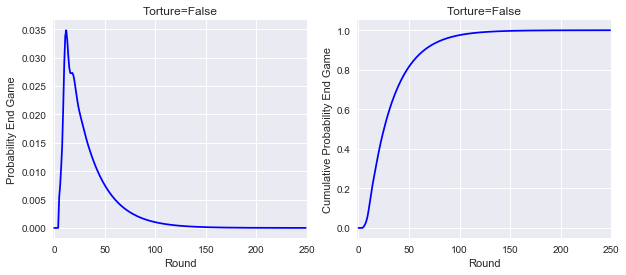

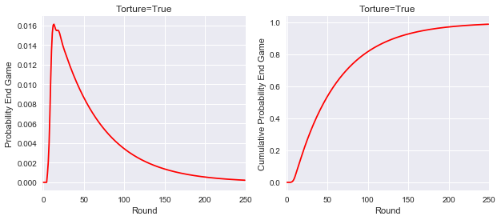

```python
# Simulation with and without torture
for torture in [False, True]:
    # PMF:
    rounds, pmf = markov_simulation(n_rounds=n_rounds, last_square=100, torture=torture)
    # CDF:
    cumulative = np.cumsum(pmf)

    # Plotting PMF and CDF respectively
    plt.figure(figsize=(10,4))

    plt.subplot(1,2,1)
    plt.plot(rounds, pmf, c='r' if torture else 'b', label='Regular')
    plt.xlim(-1, n_rounds)
    plt.ylabel('Probability End Game')
    plt.xlabel('Round')
    plt.title('Torture=%r' % torture)

    plt.subplot(1,2,2)
    plt.plot(rounds, cumulative, c='r' if torture else 'b', label='Regular')
    plt.xlim(-1, n_rounds)
    plt.ylabel('Cumulative Probability End Game')
    plt.xlabel('Round')
    plt.title('Torture=%r' % torture)
```